# Create Meme in R

Guangchuang Yu School of Public Health, The University of Hong Kong

2025-08-24

## special note for windows users

For windows users, you need to register your font before using it in R graphics (see discussion [here](https://github.com/GuangchuangYu/meme/issues/1)).

```r
if (.Platform$OS.type == "windows") {
    windowsFonts(
        Impact = windowsFont("Impact"),
        Courier = windowsFont("Courier")
    )
}
```

## `meme`

Call `meme` to add meme captions:

[figure not shown]

```r
library(meme)
u <- system.file("angry8.jpg", package="meme")
meme(u, "code", "all the things!")
```

## The grammar of meme

Not that useful, just to mimic `ggplot2`:

[figure not shown]

```r
mmplot(u) + mm_caption("calm down", "and RTFM",
                       color="purple")
```

## `meme_save`: a meme version of `ggsave`

The `meme` output can be saved as an object, and can be exported to file using `meme_save`. `meme_save` helps user setting up the output figure aspect ratio and calls `ggsave` to export the figure:

```r
u2 <- system.file("success.jpg", package="meme")
x <- meme(u2, "please", "tell me more")
```

```r
outfile <- tempfile(fileext=".png")
meme_save(x, file=outfile)
```

## `plot` method

Users can `plot` the `meme` output and change the caption or other parameters in real time.

[figure not shown]

```r
plot(x, size = 2, "happy friday!", "wait, sorry, it's monday", color = "firebrick", font = "Courier")
```

## `+` method

Instead of using parameters in `plot()` explictely, Users can use `+ list()` to set the plot parameters:

```r
x + list(upper = "#barbarplots",
        lower = "friends don't let friends make bar plots",
        color = "firebrick", font = "Courier", size=1.5)
```

[output not shown]

## multi-language support

I didn’t do anything about it. Multi-language was supported internally. Just simply select a font for your language.

[figure not shown]

```r
y <- meme(u, "卧槽", "听说你想用中文", font="STHeiti")
y
```

## grid support

[figure not shown]

```r
library(grid)
mm <- meme(u, "code", "all the things!", size=.3, color='firebrick', bgcolor=NULL)

grid.newpage()
pushViewport(viewport(width=.9, height=.9))
grid.rect(gp = gpar(lty="dashed"))

xx <- seq(0, 2*pi , length.out=10)
yy <- sin(xx)

for (i in seq_along(xx)) {
    vp <- viewport(x = xx[i]/(2*pi), y = (yy[i]-min(yy))/2, width=.05, height=.05)
    print(mm, vp = vp)
}
```

## ggplot2 support

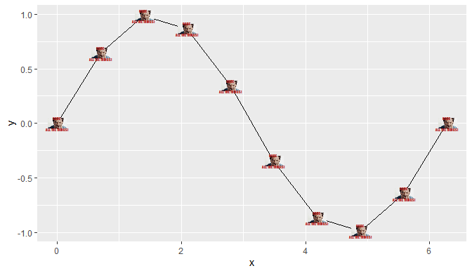

```r
library(ggplot2)
library(ggimage)

d <- data.frame(x = xx, y = yy)
ggplot(d, aes(x, y)) + geom_line() +
    geom_subview(aes(x, y), data=d, subview=mm, width=.3, height=.15)
```

[figure not shown]

```r
ggplot(d, aes(x, y)) +
    geom_subview(x = 0, y = 0, subview=mm+list(size=3), width=Inf, height=Inf) +
    geom_point() + geom_line()
```

## cowplot support

```r
library(cowplot)
plot_grid(x, y, ncol=1, labels = c("A", "B"))
```

[output not shown]

## font support

In addition to the fonts installed on your system, there are many amusing fonts that are funny for meme, *e.g.* fonts on https://fontmeme.com/fonts/.

```r
## import pokemon fonts
## downloaded from <https://fontmeme.com/fonts/pokmon-font/>
font_pokemon()
```

```
## font Pokemon_Hollow, Pokemon_Solid loaded...
```

[figure not shown]

```r
u <- system.file("ash-pikachu.0.0.jpg", package="meme")

meme(u, "Pokemon", "pikachu i choose you!", font='Pokemon_Hollow')
```

[figure not shown]

```r
meme(u, "Pokemon", "pikachu i choose you!", font='Pokemon_Solid', color='#FCCF00')
```

You can download fonts and pass the folder to `font_import()` to import the fonts so that they can be used to create meme.

```r
## folder that contains bubble1 font
## downloaded from https://fontmeme.com/fonts/bubble-1-font/
dir <- system.file('fonts/bubble', package='meme')
font_import(dir)
```

```
## font bubble1 loaded...
```

[figure not shown]

```r
meme(u, "the meme package", "is awesome!", font="bubble1")
```

Fonts imported by `font_import()` are not restricted in creating meme, you can use them in other visualization packages.

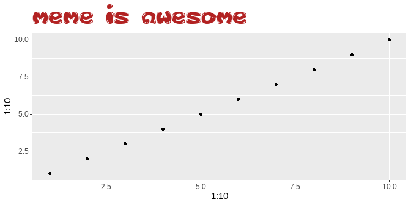

```r
qplot(1:10, 1:10) + labs(title="meme is awesome") +
    theme(plot.title=element_text(family='bubble1', size=30, color='firebrick'))
```